# Pearce et al. (2017): Updated v79i04.R Examples

Robert G Pearce, R Woodrow Setzer, Cory L Strope, Nisha S Sipes, and John F Wambaugh

2025-01-13

from “httk: R Package for High-Throughput Toxicokinetics”

Robert G Pearce, R Woodrow Setzer, Cory L Strope, Nisha S Sipes, and John F Wambaugh

Journal of Statistical Software 2017 Jul 17; 79(4): 1-26.

https://doi.org/10.18637/jss.v079.i04

*Please send questions to wambaugh.john@epa.gov*

## Abstract

Thousands of chemicals have been profiled by high-throughput screening programs such as ToxCast and Tox21; these chemicals are tested in part because most of them have limited or no data on hazard, exposure, or toxicokinetics. Toxicokinetic models aid in predicting tissue concentrations resulting from chemical exposure, and a “reverse dosimetry” approach can be used to predict exposure doses sufficient to cause tissue concentrations that have been identified as bioactive by high-throughput screening. We have created four toxicokinetic models within the R software package **httk**. These models are designed to be parameterized using high-throughput *in vitro* data (plasma protein binding and hepatic clearance), as well as structure-derived physicochemical properties and species-specific physiological data. The package contains tools for Monte Carlo sampling and reverse dosimetry along with functions for the analysis of concentration vs. time simulations. The package can currently use human *in vitro* data to make predictions for 553 chemicals in humans, rats, mice, dogs, and rabbits, including 94 pharmaceuticals and 415 ToxCast chemicals. For 67 of these chemicals, the package includes rat-specific *in vitro* data. This package is structured to be augmented with additional chemical data as they become available. Package **httk** enables the inclusion of toxicokinetics in the statistical analysis of chemicals undergoing high-throughput screening.

This vignette was created from the [R replication code v79i04.R](https://www.jstatsoft.org/index.php/jss/article/view/v079i04/3500) for the [2017 paper that introduced **httk**](https://doi.org/10.18637/jss.v079.i04).

## HTTK Version

The [R replication code v79i04.R](https://www.jstatsoft.org/index.php/jss/article/view/v079i04/3500) was created with **httk** v1.7. It was updated to a vignette using **httk** v2.2.2 in 2022. Although we attempt to maintain backward compatibility, if you encounter issues with the latest release of **httk** and cannot easily address the changes, historical versions of **httk** are available from: https://cran.r-project.org/src/contrib/Archive/httk/

## Prepare R to run the vignette

R package **knitr** generates html and PDF documents from this RMarkdown file, Each bit of code that follows is known as a “chunk”. We start by telling **knitr** how we want our chunks to look.

```r
knitr::opts_chunk$set(collapse = TRUE, comment = '#>')
options(rmarkdown.html_vignette.check_title = FALSE)
```

### Clear the memory

It is a bad idea to let variables and other information from previous R sessions float around, so we first remove everything in the R memory.

```r
rm(list=ls())
```

### eval = execute.vignette

If you are using the RMarkdown version of this vignette (extension, .RMD) you will be able to see that several chunks of code in this vignette have the statement “eval = execute.vignette”. The next chunk of code, by default, sets execute.vignette = TRUE. If execute.vignette = FALSE that would mean that the code is included (and necessary) but was not run when the vignette was built.

```r
# Set whether or not the following chunks will be executed (run):
execute.vignette <- TRUE
```

### Load the relevant libraries

We use the command ‘library()’ to load various R packages for our analysis. If you get the message “Error in library(X) : there is no package called ‘X’” then you will need to install that package:

From the R command prompt:

install.packages(“X”)

Or, if using RStudio, look for ‘Install Packages’ under ‘Tools’ tab.

```r
library(ggplot2)
library(httk)
```

Check what version of **httk** is installed:

```r
packageVersion("httk")
```

```
#> [1] '2.5.0'
```

### Control run speed

To speed up how fast these examples run, we only simulate every $N^{th}$ chemical (currently 50) – to get all chemicals with data set SKIP.CHEMS to 1:

```r
NUM.CHEMS <- length(get_cheminfo(model="pbtk", suppress.messages = TRUE))
SKIP.CHEMS <- 50
```

```r
NSAMP <- 10
```

# Examples

To get a list of parameters for the pbtk model of Triclosan in a rat:

```r
parameters <- try(parameterize_pbtk(chem.name = "triclosan",
                                    species = "rat"))
```

```
#> Error in check_model(chem.cas = chem.cas, chem.name = chem.name, dtxsid = dtxsid,  :
#>   Chemical CAS: 3380-34-5, DTXSID: DTXSID5032498, named: triclosan has insufficient parameters for model pbtk. Try setting default.to.human=TRUE. See also help(get_cheminfo)
```

We do not have a full set of *in vitro* parameters for rat for Triclosan, so we fill in the *in vitro* measured values with human-derived measurements and use rat physiological parameters by setting “default.to.human = TRUE”:

```r
parameters <- parameterize_pbtk(chem.name = "triclosan",
                                species = "rat",
                                default.to.human = TRUE)
```

To change the $f_{up}$ in the previous parameters list to 0.001 from the human value of 0.003044 and use it in a simulation of the PBTK model for a single dose of 1 mg/kg BW of Triclosan in a rat:

```r
parameters["Funbound.plasma"] <- 0.001
out <- solve_pbtk(parameters = parameters, suppress.messages = TRUE)
```

## Making a table

In the example below, setting model to “pbtk” in “get_cheminfo” removes the chemicals from the list with $f_{up}$ below the limit of detection which have been set to zero because the model uses partition coefficients that are calculated with $f_{up}$. However, we could include all chemicals that work with the models without partition coefficients by using the default option of “3compartmentss” or setting exclude.fup.zero to false, and $f_{up}$ would then automatically be set to 0.005.

First we make up a list of chemicals with both literature $C_{ss}$ values and HTTK data for making new $C_{ss}$ predictions:

```r
chem.list <- intersect(get_cheminfo(model = "pbtk",
                                    suppress.messages = TRUE)[seq(
                                      1, NUM.CHEMS, SKIP.CHEMS)],
                       get_wetmore_cheminfo())
```

Then we initialize a NULL table and build it up one row at a time:

```r
css.table <- NULL
for (this.cas in chem.list)
{
    ids <- get_chem_id(chem.cas=this.cas)
    this.row <- data.frame(Compound=ids$chem.name,
                              DTXSID=ids$dtxsid,
                              CAS=this.cas)
    this.row <- cbind(this.row,
                      as.data.frame(calc_analytic_css(chem.cas = this.cas,
                                                      model = "pbtk",
                                                      output.units = "uM",
                                                      suppress.messages=TRUE)))
    this.row <- cbind(this.row,
                      as.data.frame(get_wetmore_css(chem.cas = this.cas,
                                                    which.quantile = 0.50,
                                                    output.units = "uM",
                                                    suppress.messages=TRUE)))
    this.row <- cbind(this.row,
                      as.data.frame(calc_mc_css(chem.cas = this.cas,
                                                which.quantile = 0.50,
                                                output.units = "uM",
                                                samples = NSAMP,
                                                suppress.messages=TRUE)))
    css.table <- rbind(css.table, this.row)
}
colnames(css.table) <- c("Compound","DTXSID","CAS", "PBTK", "Wetmore", "MC")
```

Now display the table and plot two columns against each other:

```r
knitr::kable(css.table, caption = "Literature and HTTK Plasma Css",
             floating.environment="sidewaystable",
             row.names=FALSE,
             digits=3)
```

Literature and HTTK Plasma Css

| Compound | DTXSID | CAS | PBTK | Wetmore | MC |
| --- | --- | --- | --- | --- | --- |
| 2,4-d | DTXSID0020442 | 94-75-7 | 40.550 | 43.320 | 53.020 |
| Diethyltoluamide | DTXSID2021995 | 134-62-3 | 0.958 | 0.847 | 1.862 |
| Isoxaben | DTXSID8024159 | 82558-50-7 | 0.962 | 24.460 | 1.111 |
| Rotenone | DTXSID6021248 | 83-79-4 | 2.232 | 1.833 | 2.832 |
| Genistein | DTXSID5022308 | 446-72-0 | 1.109 | 0.310 | 1.146 |
| Coumarin | DTXSID7020348 | 91-64-5 | 0.430 | 0.424 | 20.720 |

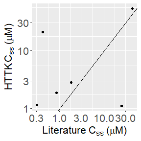

```r
litvshttkcss <- ggplot(css.table, aes(Wetmore, MC)) +
    geom_point() + geom_abline() +
    scale_x_log10() + scale_y_log10() +
    xlab(bquote("Literature"~C[ss]~"("*mu*"M)")) +
    ylab(bquote("HTTK"~C[ss]~"("*mu*"M)")) +
    theme(axis.text = element_text(size = 16),
          axis.title = element_text(size = 16))
print(litvshttkcss)
```

## Plotting example

To see how $C_{ss}$ resulting from discrete dosing deviates from the average steady state concentration, we can make a plot with **ggplot2** that includes a horizontal line through the $y$-axis at the predicted $C_{ss}$ for oral infusion dosing (Figure 2 in Pearce et al., 2017).

```r
out <- solve_pbtk(chem.name = "Bisphenol A",
                  days = 50,
                  doses.per.day = 3,
                  daily.dose=1,
                  output.units = "uM")
```

```r
plot.data <- as.data.frame(out)

css <- calc_analytic_css(chem.name = "Bisphenol A",
                  output.units = "uM")
```

[output not shown]

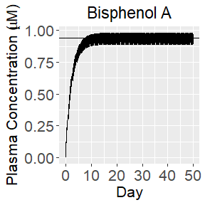

```r
c.vs.t <- ggplot(plot.data, aes(time, Cplasma)) +
    geom_line() + geom_hline(yintercept = css) +
    ylab(bquote("Plasma Concentration ("*mu*"M)")) +
    xlab("Day") +
    theme(axis.text = element_text(size = 16),
          axis.title = element_text(size = 16),
          plot.title = element_text(size = 17, hjust=0.5)) +
    ggtitle("Bisphenol A")
print(c.vs.t)
```

### Suppressing Messages

Note that since *in vitro-in vivo* extrapolation (IVIVE) is built upon many, many assumptions, *httk** attempts to give many warning messages by default. These messages do not usually mean something is wrong, but are rather intended to make the user aware of the assumptions involved. However, they quickly grow annoying and can be turned off with the “suppress.messages=TRUE” argument. Proceed with caution…

```r
out <- solve_pbtk(chem.name = "Bisphenol A",
                  days = 50,
                  doses.per.day = 3,
                  daily.dose=1,
                  output.units = "uM",
                  suppress.messages = TRUE)

css <- calc_analytic_css(chem.name = "Bisphenol A",
                  output.units = "uM",
                  suppress.messages = TRUE)
```

## TK Study Summary Statistics

“calc_tk_stats” allows summary TK statistics to be calculated for a specific study design (including dose regiment, duration, and species). The following code calculates the peak plasma concentration for all chemicals in **httk** simulated for 10 days at 1 mg/kg BW/day with 3 doses per day. Note that the function “calc_stats” was renamed “calc_tk_stats” in a later release of **httk**.

```r
all.peak.stats <- calc_stats(days = 10, doses.per.day = 3, stats = "peak")
```

The same function can be used for a single chemical. For example, the AUC, peak, and mean for a single 1 mg dose of Triclosan over 10 day:

```r
triclosan.stats <- calc_stats(days = 10, chem.name = "triclosan")
```

## Steady-state Plasma Concentration

Below are examples of two functions,comparing the medians of the Wetmore data in humans for 1 mg/kg BW/day of Bisphenol A with the “calc_mc_css” simulation with probability distributions containing a third of the standard deviation, half the limit of detection for $f_{up}$, and the same number of samples of the parameters used in [Wetmore et al. (2012)](https://doi.org/10.1093/toxsci/kfr254).

We use make use of the default Monte Carlo sampler by setting argument “httkpop=FALSE” to turn off httk-pop ([Ring et al., 2017](https://doi.org/10.1016/j.envint.2017.06.004)) and “invitrouv=FALSE” to turn off uncertainty/variability for the *in vitro* parameters ([Wambaugh et al., 2019](https://doi.org/10.1093/toxsci/kfz205)).

Note that the function “get_wetmore_css” was renamed “get_lit_css” in a later release of **httk**.

```r
get_wetmore_css(chem.cas = "80-05-7", daily.dose = 1,
                which.quantile = 0.5, output.units = "uM")
set.seed(654321)
calc_mc_css(chem.cas = "80-05-7",
            daily.dose = 1,
            which.quantile = 0.5,
            censored.params = list(
              Funbound.plasma = list(cv = 0.1, lod = 0.005)),
            vary.params = list(
              BW = 0.15,
              Vliverc = 0.15,
              Qgfrc = 0.15,
              Qtotal.liverc = 0.15,
              million.cells.per.gliver = 0.15,
              Clint = 0.15),
            output.units = "uM",
            samples = NSAMP,
            httkpop=FALSE,
            invitrouv=FALSE,
            suppress.messages = TRUE)
```

### Using more sophisticated Monte Carlo

**httk** uses Monte Carlo to simulate population variability and propagate parameter uncertainty. The algorithm for population variability, “httk-pop” [(Ring et al., 2017)](https://doi.org/10.1016/j.envint.2017.06.004) simulates population variability in TK by predicting distributions of physiological parameters based on distributions of demographic and biometric quantities from the National Health and Nutrition Examination Survey (NHANES), conducted by the U.S. Centers for Disease Control and Prevention (CDC). MEthods for propagating uncertainty in *in vitro* measurements were described by [Wambaugh et al. (2019)](https://doi.org/10.1093/toxsci/kfz205).

Both httk-pop and *in vitro* uncertainty/variability simulation, are on by default:

```r
set.seed(654321)
calc_mc_css(chem.cas = "80-05-7",
            daily.dose = 1,
            which.quantile = 0.5,
            output.units = "uM",
            samples = NSAMP,
            suppress.messages = TRUE)
```

### Controlling the random number generator

Any of the Monte Carlo functions in **httk**, often indicated by the inclusion of “mc” in the function name, make use of random draws from distributions to simulate uncertainty and variability. The random number generator in any computer is actually a pseudo-random number generator that creates a sequence of nearly uncorrelated numbers, but that sequence can be recreated at any time if we set a random number generator “seed”. In R we control the seed with the function “set.seed”, which allows us to get the same Monte Carlo output again and again (and in many cases on different computers). The seed can take any value, and if you use the same seed followed by the same functions called in the same order with the same arguments, you will get the same answer again and again:

```r
# Random number generator seed 1:
set.seed(654321)
calc_mc_css(chem.cas = "80-05-7",
            daily.dose = 1,
            which.quantile = 0.5,
            output.units = "uM",
            samples = NSAMP,
            suppress.messages = TRUE)
```

```r
# Continuing to draw random numbers without resetting the seed:
calc_mc_css(chem.cas = "80-05-7",
            daily.dose = 1,
            which.quantile = 0.5,
            output.units = "uM",
            samples = NSAMP,
            suppress.messages = TRUE)
# Random number generator seed 2:
set.seed(123456)
calc_mc_css(chem.cas = "80-05-7",
            daily.dose = 1,
            which.quantile = 0.5,
            output.units = "uM",
            samples = NSAMP,
            suppress.messages = TRUE)
# Continuing to draw random numbers without resetting the seed:
calc_mc_css(chem.cas = "80-05-7",
            daily.dose = 1,
            which.quantile = 0.5,
            output.units = "uM",
            samples = NSAMP,
            suppress.messages = TRUE)
# Random number generator seed 2 gives the same answer as it did above:
set.seed(123456)
calc_mc_css(chem.cas = "80-05-7",
            daily.dose = 1,
            which.quantile = 0.5,
            output.units = "uM",
            samples = NSAMP,
            suppress.messages = TRUE)
# Random number generator seed 1 gives the same answer as it did above:
set.seed(654321)
calc_mc_css(chem.cas = "80-05-7",
            daily.dose = 1,
            which.quantile = 0.5,
            output.units = "uM",
            samples = NSAMP,
            suppress.messages = TRUE)
```

[output not shown]

## IVIVE with HTTK

Simple “reverse dosimetry” *in vitro-in vivo* extrapolation (IVIVE) determines an administered equivalent dose (AED) by taking an *in vitro* concentration $C_{\text{in vitro}}$ (50 uM in the example below) and dividing it by the steady-state plasma concentration $C_{ss}$ produced by a dose rate of 1 mg/kg bw/day:

$$AED = \frac{C_{\text{in
vitro}}}{C_{ss}}$$

We can also calculate the AED using literature values or sampling with **httk**:

```r
get_wetmore_oral_equiv(50, chem.cas = "80-05-7")
set.seed(654321)
calc_mc_oral_equiv(50, chem.cas = "80-05-7", samples = NSAMP)
```

### Monte Carlo Simulation of $C_{ss}$

We can perform a Monte Carlo simulation on Zoxamide with the model pbtk with the same limit of detection and coefficients of variation (cv). Note, the function “monte_carlo” was replaced with a similar function “calc_mc_tk” for simulation concentration timecourses, while arguments were added to “calc_mc_css” that allowed the functionality seen in the 2017 paper. Separately, a new function “monte_carlo” was created to complement “httkpop_mc” and “invitro_mc” as part of “create_mc_samples”. “monte_carlo” varies parameters according to a normal distribution with given mean and coefficient of variation or according to a censored distribution with an additional limit of detection parameter. Note that we again turn off httkpop and invitrouv to replicate the 2017 version of Monte Carlo.

First we create a list of parameters and then assign a coefficient of variation to each parameter we wish to vary:

```r
vary.params <- NULL
params <- parameterize_pbtk(chem.name = "Zoxamide")
for (this.param in names(subset(params, names(params) != "Funbound.plasma")))
  # Only want to vary numerical parameters:
  if (is.numeric(params[[this.param]]))
      vary.params[this.param] <- 0.2
```

We can draw $f_{up}$ from a censored distribution with a limit of dextion (LOD) of 0.01:

```r
censored.params <- list(Funbound.plasma = list(cv = 0.2, lod = 0.01))
```

### Solve the full TK time-course

```r
set.seed(1)
out <- calc_mc_tk(parameters=params,
                  vary.params = vary.params,
                  censored.params = censored.params,
                  return.samples = TRUE,
                  model = "pbtk",
                  suppress.messages = TRUE,
                  httkpop = FALSE,
                  invitrouv = FALSE,
                  samples = NSAMP,
                  solvemodel.arg.list = list(times = seq(0,0.5,0.025))
                  )
```

Make a table of concentration vs. time with confidence intervals:

```r
zoxtable <- cbind(out[["means"]][,"time"],
                  out[["means"]][,"Cplasma"],
                  out[["means"]][,"Cplasma"] - 1.96*out[["sds"]][,"Cplasma"],
                  out[["means"]][,"Cplasma"] + 1.96*out[["sds"]][,"Cplasma"])
colnames(zoxtable) <- c("time","Cplasma","lcl","ucl")
knitr::kable(zoxtable, caption = "Zoxamide plasma concentration vs. time",
             floating.environment="sidewaystable")
```

Zoxamide plasma concentration vs. time

| time | Cplasma | lcl | ucl |
| --- | --- | --- | --- |
| 0.0000 | 0.0000000 | 0.0000000 | 0.0000000 |
| 0.0001 | 0.0000137 | 0.0000074 | 0.0000200 |
| 0.0250 | 0.4607000 | 0.3591132 | 0.5622868 |
| 0.0500 | 0.5514000 | 0.4394252 | 0.6633748 |
| 0.0750 | 0.5804000 | 0.4646228 | 0.6961772 |
| 0.1000 | 0.5973000 | 0.4789748 | 0.7156252 |
| 0.1250 | 0.6098000 | 0.4897108 | 0.7298892 |
| 0.1500 | 0.6199000 | 0.4983212 | 0.7414788 |
| 0.1750 | 0.6281000 | 0.5054040 | 0.7507960 |
| 0.2000 | 0.6350000 | 0.5111868 | 0.7588132 |
| 0.2250 | 0.6407000 | 0.5160440 | 0.7653560 |
| 0.2500 | 0.6454000 | 0.5199600 | 0.7708400 |
| 0.2750 | 0.6492000 | 0.5231720 | 0.7752280 |
| 0.3000 | 0.6525000 | 0.5258840 | 0.7791160 |
| 0.3250 | 0.6552000 | 0.5280548 | 0.7823452 |
| 0.3500 | 0.6574000 | 0.5298628 | 0.7849372 |
| 0.3750 | 0.6592000 | 0.5313492 | 0.7870508 |
| 0.4000 | 0.6607000 | 0.5325160 | 0.7888840 |
| 0.4250 | 0.6620000 | 0.5335612 | 0.7904388 |
| 0.4500 | 0.6630000 | 0.5343652 | 0.7916348 |
| 0.4750 | 0.6638000 | 0.5349692 | 0.7926308 |
| 0.5000 | 0.6645000 | 0.5355320 | 0.7934680 |

Plot Monte Carlo analysis of concentration vs. time:

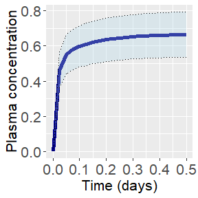

```r
zoxamide1 <- ggplot(as.data.frame(zoxtable), aes(x=time,y=Cplasma)) +
    geom_line(color = "dark blue",linewidth=2) +
      geom_ribbon(aes(ymin=lcl, ymax=ucl), alpha = 0.3,
                  fill = "light blue", color="black", linetype="dotted")+
    ylab("Plasma concentration") +
    xlab("Time (days)") +
    theme(axis.text = element_text(size = 16),
          axis.title = element_text(size = 16))
print(zoxamide1)
```

### Examine $C_{ss}$

```r
out <- calc_mc_css(parameters=params,
                  vary.params = vary.params,
                  censored.params = censored.params,
                  return.samples = TRUE,
                  model = "pbtk",
                  suppress.messages = TRUE,
                  httkpop = FALSE,
                  samples = NSAMP,
                  invitrouv = FALSE)
```

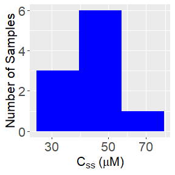

```r
zoxamide2 <- ggplot(as.data.frame(out), aes(out)) +
    geom_histogram(fill = "blue", binwidth = 1/6) +
    scale_x_log10() + ylab("Number of Samples") +
    xlab(bquote(C[ss]~"("*mu*"M)")) +
    theme(axis.text = element_text(size = 16),
          axis.title = element_text(size = 16))
print(zoxamide2)
```

## Adding a tissue

The **httk** package contains a data.frame called tissue.data that describes the composition of various tissues in terms of the [Schmitt (2008)](https://doi.org/10.1016/j.tiv.2007.09.010) mechanistic model for deriving tissue:plasma partition coefficients. Once described, these tissues are available for use as compartments in new models or to be lumped into the rest of body in existing models (using function “lump_tissues”). We can add a new tissue (for example, mammary) to the tissue data by replicating the data from another tissue and adjusting as appropriate.

```r
new.tissue <- subset(tissue.data,Tissue == "adipose" & Species =="Human")
new.tissue[, "Tissue"] <- "mammary"
new.tissue[new.tissue$variable=="Vol (L/kg)","value"] <-
  320/1000/60 # Itsukage et al. (2017) PMID: 29308107
new.tissue[new.tissue$variable %in% c('Flow (mL/min/kg^(3/4))'),'value'] <-
# We'll arbitrarily set flow to a tenth of total adipose:
  new.tissue[new.tissue$variable %in% c('Flow (mL/min/kg^(3/4))'),'value']/10
tissue.data <- rbind(tissue.data, new.tissue)
knitr::kable(subset(tissue.data,Tissue=="mammary"),
             caption = "Approximate Mamary Tissue Parameters",
             floating.environment="sidewaystable",
             row.names=FALSE,
             digits=3)
```

Approximate Mamary Tissue Parameters

| Tissue | Species | Reference | variable | value |
| --- | --- | --- | --- | --- |
| mammary | Human | Schmitt 2008 | Fcell | 0.860 |
| mammary | Human | Schmitt 2008 | Fint | 0.140 |
| mammary | Human | Schmitt 2008 | FWc | 0.020 |
| mammary | Human | Schmitt 2008 | FLc | 0.934 |
| mammary | Human | Schmitt 2008 | FPc | 0.046 |
| mammary | Human | Schmitt 2008 | Fn_Lc | 0.936 |
| mammary | Human | Schmitt 2008 | Fn_PLc | 0.056 |
| mammary | Human | Schmitt 2008 | Fa_PLc | 0.008 |
| mammary | Human | Schmitt 2008 | pH | 7.100 |
| mammary | Human | EPA, Physiological Parameters Database for PBPK Modeling | Density (g/cm^3) | 0.916 |
| mammary | Human | ILSI-RSI 1994 | Vol (L/kg) | 0.005 |
| mammary | Human | Davies and Morris 1993 | Flow (mL/min/kg^(3/4)) | 1.074 |

If we thought this tissue had been included in the rest of body total previously we could consider removing it from those volumes and flows, but we won’t do that here (Note eval=FALSE):

```r
# If we thought this tissue was included in the rest of the bod
tissue.data[tissue.data$Tissue == "rest", 'value'] <-
  tissue.data[tissue.data$Tissue == "rest", 'value'] -
  new.tissue[new.tissue$variable %in% c(
    'Vol (L/kg)',
    'Flow (mL/min/kg^(3/4))'),
    'value']
```

To generate the parameters for a model with kidneys, thyroid, brain, breast, liver compartment combining the liver and gut, and a rest of body compartment:

```r
compartments <- list(liver = c("liver", "gut"), kidney = "kidney",
                     breast = "mammary", brain = "brain",
                     thyroid = "thyroid")
tissues.to.include <- unique(tissue.data$Tissue)
tissues.to.include <- tissues.to.include[!(tissues.to.include=="placenta")]
Kp <- predict_partitioning_schmitt(
  chem.name = "Nicotine",
  tissues = tissues.to.include,
  suppress.messages = TRUE)
lumped.params <- lump_tissues(Kp, tissuelist=compartments)
knitr::kable(as.data.frame(lumped.params),
             caption = "PCs, Volumes, and Flows for Lumped Tissues",
             floating.environment="sidewaystable",
             row.names=FALSE,
             digits=3)
```

PCs, Volumes, and Flows for Lumped Tissues

| Krbc2pu | Kliver2pu | Kkidney2pu | Kbreast2pu | Kbrain2pu | Kthyroid2pu | Krest2pu | Vliverc | Vkidneyc | Vbreastc | Vbrainc | Vthyroidc | Vrestc | Qtotal.liverf | Qkidneyf | Qbreastf | Qbrainf | Qthyroidf | Qrestf | Qgutf |
| --- | --- | --- | --- | --- | --- | --- | --- | --- | --- | --- | --- | --- | --- | --- | --- | --- | --- | --- | --- |
| 0.802 | 4.749 | 5.149 | 11.61 | 1.451 | 1.448 | 1.916 | 0.04 | 0.004 | 0.005 | 0.019 | 0 | 0.764 | 0.464 | 0.221 | 0.005 | 0.125 | 0.016 | 0.376 | 0.205 |

## Adding a species

The **httk** package contains a data.frame called physiology.data that describes the species-specific aspects of physiology necessary to parameterize a PBTK model. We can add a new species (for example, wolverines) to the physiology.data by replicating the data from another species and adjusting as appropriate.

```r
new.species <- physiology.data[,"Rabbit"]
names(new.species) <- physiology.data[,"Parameter"]
rabbit.BW <- new.species["Average BW"]
new.species["Average BW"] <- 31.2 # Rausch and Pearson (1972) https://doi.org/10.2307/3799057
new.species["Average Body Temperature"] <- 38.5 # Thiel et al. (2019) https://doi.org/10.1186/s12983-019-0319-8

physiology.data <- cbind(physiology.data, new.species)
colnames(physiology.data)[length(colnames(physiology.data))] <- "Wolverine"

knitr::kable(physiology.data[,c("Parameter","Units","Wolverine")],
             caption = "Approximate Wolverine Physiological Parameters",
             floating.environment="sidewaystable",
             row.names=FALSE,
             digits=3)
```

Approximate Wolverine Physiological Parameters

| Parameter | Units | Wolverine |
| --- | --- | --- |
| Total Body Water | ml/kg | 716.000 |
| Plasma Volume | ml/kg | 44.000 |
| Cardiac Output | ml/min/kg^(3/4) | 212.000 |
| Average BW | kg | 31.200 |
| Total Plasma Protein | g/ml | 0.057 |
| Plasma albumin | g/ml | 0.039 |
| Plasma a-1-AGP | g/ml | 0.001 |
| Hematocrit | fraction | 0.360 |
| Urine | ml/min/kg^(3/4) | 0.042 |
| Bile | ml/min/kg^(3/4) | 0.083 |
| GFR | ml/min/kg^(3/4) | 3.120 |
| Average Body Temperature | C | 38.500 |
| Plasma Effective Neutral Lipid Volume Fraction | unitless | 0.002 |
| Plasma Protein Volume Fraction | unitless | 0.057 |
| Pulmonary Ventilation Rate | l/h/kg^(3/4) | 24.750 |
| Alveolar Dead Space Fraction | unitless | 0.330 |
| Small Intestine Mean Residence Time | min | NA |
| Small Intestine Radius | cm | NA |

The tissue volumes and flows are stored separately in tissue.data. Physiological parameters are in the table physiology.data.

```r
new.tissue.data <- subset(tissue.data,Species=="Rabbit")
new.tissue.data$Species <- "Wolverine"

tissue.data <- rbind(tissue.data,new.tissue.data)

new.physiology.data <- physiology.data[,"Rabbit"]
physiology.data <- rbind(physiology.data, new.physiology.data)
colnames(physiology.data)[length(colnames(physiology.data))] <- "Wolverine"
```

Now we can make predictions for wolverines!

```r
calc_mc_css(chem.cas="80-05-7",species="wolverine",
            parameterize.arg.list=list(default.to.human=TRUE),
            suppress.messages=TRUE,
            samples = NSAMP)
```

## Export functions

Jarnac [(Sauro and Fell 2000)](http://academic.sun.ac.za/natural/biochem/btk/book/Sauro.pdf) and SBML [(Hucka et al. 2003)](https://doi.org/10.1093/bioinformatics/btg015) are commonly used languages for systems biology models of cellular and physiological processes. In the event that a modeler wishes to couple such a model to a toxicokinetic model, we provide functions to export model equations and chemical-specific parameters to these languages. The two functions, “export_pbtk_sbml” and “export_pbtk_jarnac”, have the same arguments and only differ in the file extension names (.xml and .jan) entered into the filename argument. Both use liters as the units for volume, but the amounts are unitless and to be determined by the user. If we suppose that we enter an initial amount of 1 mg in the gut lumen, then all the other compartments will contain amounts in mg.

Below is a call of an export function for a dose of 1 given to a rat:

```r
export_pbtk_sbml(chem.name = "Bisphenol A", species = "Rat",
                 initial.amounts = list(Agutlumen = 1),
                 filename = "PBTKmodel.xml")
```

## Days to steady state histogram

Creating histograms can allow us to visualize how a given value varies across all the chemicals contained within the package. To create a histogram using **ggplot2** of the number of days to steady state, we must first set up a for loop with “get_cheminfo” and “calc_css” to generate a vector containing the data. Vectors containing the average and maximum concentrations at steady state are also generated in this example, avg and max. The data contained in the days vector are then plotted as a histogram (Pearce et al., (2017) Figure 3). We can just as easily create a histogram containing the average or maximum steady state concentrations by substituting avg or max for days.

```r
css.data <- data.frame()
chem.list <- get_cheminfo(model='pbtk', suppress.messages = TRUE)[seq(
  1, NUM.CHEMS, SKIP.CHEMS)]
for (this.cas in chem.list) {
    css.info <- calc_css(chem.cas = this.cas,
                         doses.per.day = 1,
                         model="pbtk",
                         suppress.messages = TRUE)
    css.data[this.cas,"days"] <- css.info[["the.day"]]
    css.data[this.cas,"avg"] <- css.info[["avg"]]
    css.data[this.cas,"max"] <- css.info[["max"]]
}
```

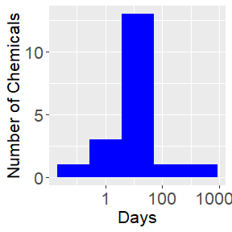

```r
hist <- ggplot(css.data, aes(days+0.1)) +
    geom_histogram(fill = "blue", bins=5) +
    scale_x_log10() + ylab("Number of Chemicals") + xlab("Days") +
    theme(axis.text = element_text(size = 16),
          axis.title = element_text(size = 16))
print(hist)
```

## Average vs. maximum concentration

We can compare the average and maximum concentrations at steady state using the average and maximum concentration at steady state vectors, avg and max, from the previous example. The vectors are bound into a data frame and plotted with a line through the origin with a slope of 1 (Pearce et al. (2017) Figure 4).

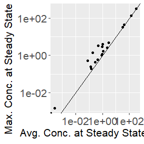

```r
avg.vs.max <- ggplot(css.data, aes(avg, max)) +
    geom_point() + geom_abline() +
    scale_x_log10() + scale_y_log10() +
    xlab(bquote("Avg. Conc. at Steady State ("*mu*"M)")) +
    ylab(bquote("Max. Conc. at Steady State ("*mu*"M)")) +
    theme(axis.text = element_text(size = 16),
          axis.title = element_text(size = 16))
print(avg.vs.max)
```